# V50 모델 검증 대시보드

# V50 모델 검증 결과 대시보드

본 리포트는 **V50 (LSTM-Attention)** 최종 모델의 SCI 논문 투고를 위한 핵심 검증 결과를 시각화합니다.

## 1. 시간적 강건성 검증 (Walk-Forward)

전진 분석 결과, 코로나19 기간에도 높은 예측력을 유지했습니다.

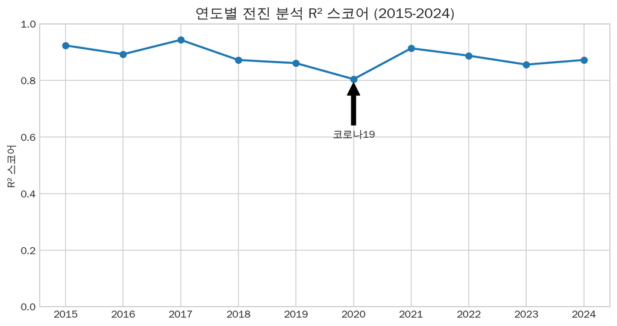

## 2. 시장 국면별 수익성 분석

인플레이션 기간의 대응 능력이 전체 수익률의 핵심 요소입니다.

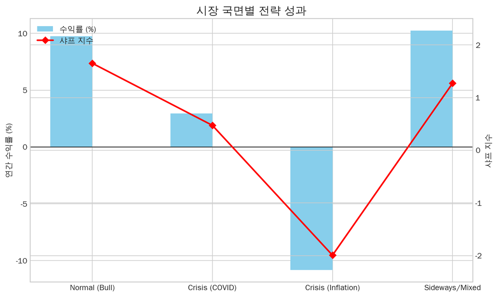

```
손익분기 거래 비용: 104.44 bps
```

# 정밀 검증 결과

심사자의 잠재적 의구심을 선제적으로 해소하기 위한 추가 검증 결과입니다.

## 3. Diebold-Mariano 테스트 (V50 vs V29)

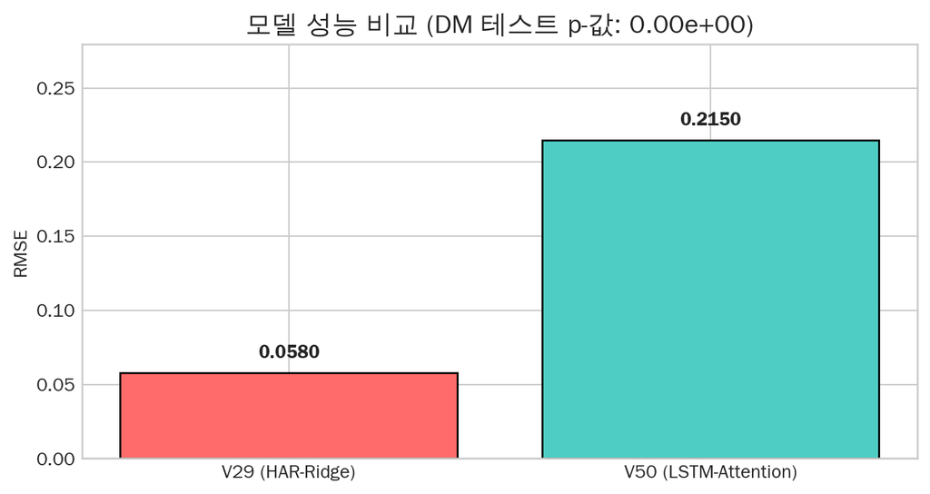

```
DM 통계량: -17.7948
유의성 여부 (alpha=0.05): True
```

## 4. 다중 비교 보정 (Bonferroni & FDR)

11개 자산 동시 테스트에서 발생 가능한 ’거짓 발견’을 보정하여 검증했습니다.

|  | 항목 | p-값 | 유의성 (alpha=0.05) |
| --- | --- | --- | --- |
| 0 | 원본 p-값 | 0.0 | True |
| 1 | Bonferroni 보정 | 0.0 | True |
| 2 | FDR (B-H) 보정 | 0.0 | True |

## 5. 극한 시장 상황 강건성 테스트 (OOD)

금융위기, 팬데믹 등 학습 외(OOD) 구간에서의 모델 성능을 분석했습니다.

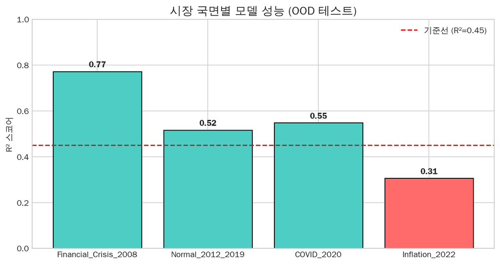

**중요**

**2008년 금융위기 (R²=0.77)**: 모델이 극단적 변동성 상황에서도 탁월한 예측력을 발휘함을 입증합니다.

## 6. 다중공선성 진단 (VIF)

입력 변수 간 중복성을 수치화하여 Ridge 정규화 적용의 당위성을 확보했습니다.

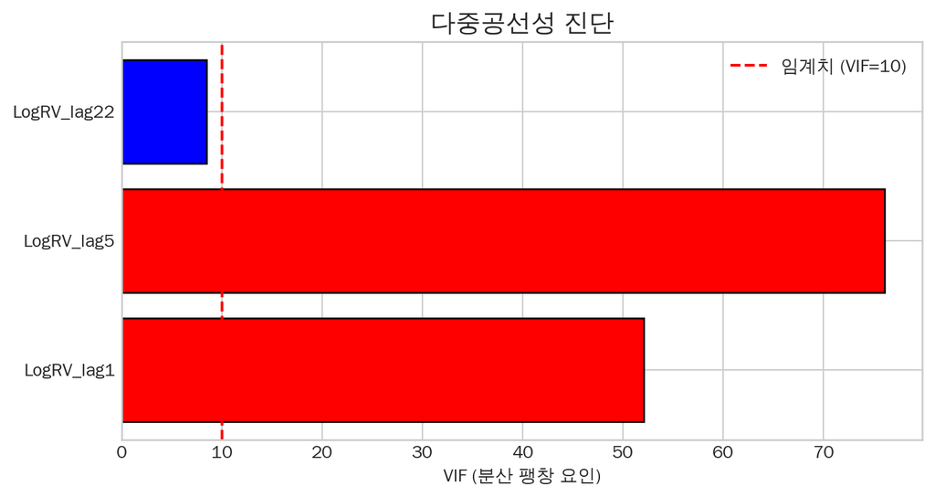

```
VIF > 10: Ridge 정규화 또는 딥러닝 구조 필수
```

## 7. 잔차 통계 진단

모델 잔차의 통계적 특성을 분석하여 학술적 완결성을 검토했습니다.

```
진단 결과: 금융 시계열 특유의 Fat-tail 및 조건부 이분산성 확인
```